# Questionnaire Report for Canary rockfish

## Catch reporting bias

| Answered |
| --- |
| Strong under-reporting (30% - 50%) |
| Under-reporting (10% - 30%) |
| Slight under-reporting (0% - 10%) |
| Reported accurately (+/- 5%) |
| Slight over-reporting (less than 10%) |

Justification

“Even with good catch data in the period 1996+, CPUE can be expected to be “hyper-stable” within the context of an individual vessel quota (IVQ) fishery (IVQs were introduced in 1997). As canary rockfish abundance varies, fishers in an IVQ fishery are likely to alternate between targeting and avoiding this species in response to changes in abundance, thus making CPUE appear to be stable. However, we assume this tendency towards hyper-stability would be overwhelmed by large-scale changes in abundance, particularly for declines because, at some point, IVQs will not be caught if abundance declines significantly. This should be manifest in the CPUE as well. Therefore, these analyses were conducted to examine whether there was evidence of a decline large enough to overcome the tendency for hyper-stability." (COSEWIC 2007)

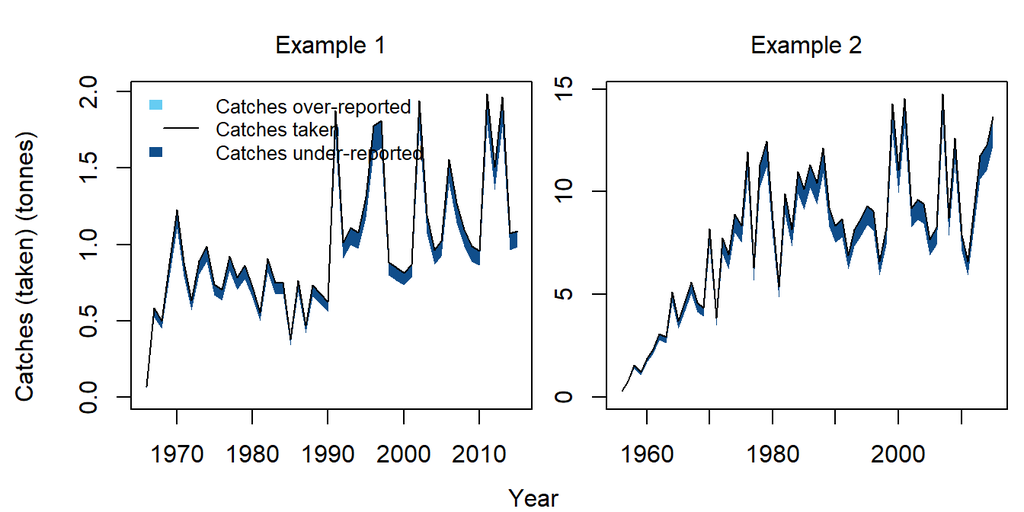

## Hyperstability in indices

| Answered |
| --- |
| Strong hyperdepletion (2 < Beta < 3) |
| Hyperdepletion (1.25 < Beta < 2) |
| Proportional (0.8 < Beta < 1.25) |
| Hyperstability (0.5 < Beta < 0.8) |
| Strong hyperstability (0.33 < Beta < 0.5) |

Justification

“Even with good catch data in the period 1996+, CPUE can be expected to be “hyper-stable” within the context of an individual vessel quota (IVQ) fishery (IVQs were introduced in 1997). As canary rockfish abundance varies, fishers in an IVQ fishery are likely to alternate between targeting and avoiding this species in response to changes in abundance, thus making CPUE appear to be stable. However, we assume this tendency towards hyper-stability would be overwhelmed by large-scale changes in abundance, particularly for declines because, at some point, IVQs will not be caught if abundance declines significantly. This should be manifest in the CPUE as well. Therefore, these analyses were conducted to examine whether there was evidence of a decline large enough to overcome the tendency for hyper-stability." (COSEWIC 2007)

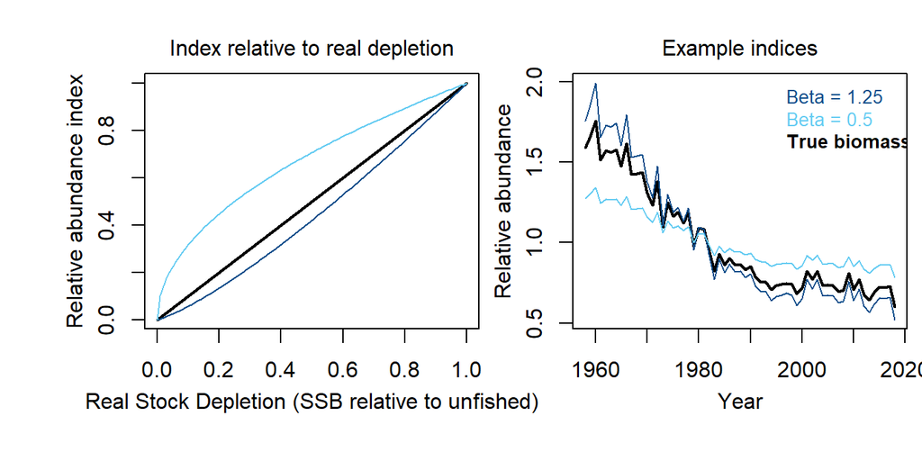

## Available data types

| Answered |
| --- |
| Perfect |
| Good (accurate and precise) |
| Data moderate (some what inaccurate and imprecise) |
| Data poor (inaccurate and imprecise) |

[output not shown]

# Version Notes

The package is subject to ongoing testing. If you find a bug or a problem please send a report to t.carruthers@oceans.ubc.ca so that it can be fixed!

tcar_-2019-11-26-10:25:40

Open Source, GPL-2 2019